# Genetic diversity practical

Chloe Schmidt

2023-04-24

## Part 2: Drivers of genetic diversity change

##### How does urbanization affect birds and mammal genetic diversity?

```r
# Libraries
library(ggplot2)  # plotting

library(lme4)     # modeling
library(lmerTest) # modeling

source('other_functions.R')
```

### Load the data

Genetic diversity metrics for mammals (41 species) and birds (25 species) sampled at 1008 locations in the US and Canada.

Data is from: Schmidt et al. (2020) “Continent-wide effects of urbanization on bird and mammal genetic diversity.” Proc B 287(1920)

paper: https://royalsocietypublishing.org/doi/full/10.1098/rspb.2019.2497#d1e1557

data: https://datadryad.org/stash/dataset/doi:10.5061/dryad.cz8w9gj0c

**Genetic diversity metrics:**

- gene_diversity = gene diversity
- allelic_richness = allelic richness rarefied to a minimum of 10 alleles (the minimum across all datasets)
- global_fst = population-specific FST

**Urbanization variables:**

- urban = binary variable; 0 = non-urban, 1 = urban
- popden = human population density
- hfi = Human Footprint Index (0 = most wild; 100 = most transformed)

```r
dat <- read.csv('data/synthesized_geneticdiversity_dryad.csv', header=T)

head(dat)
```

```
##         pop  author                species  class      lat        lon
## 1         1 Johnson Myotis_septentrionalis mammal       NA         NA
## 2  1_Reding  Reding             Lynx_rufus mammal 34.75524  -93.49529
## 3        10 Johnson Myotis_septentrionalis mammal       NA         NA
## 4 10_Reding  Reding             Lynx_rufus mammal 46.32069 -103.09493
## 5        11 Johnson Myotis_septentrionalis mammal       NA         NA
## 6 11_Reding  Reding             Lynx_rufus mammal 34.34591 -107.40565
##                   geo_meth num_individuals gene_diversity allelic_richness
## 1              coordinates              38       0.871393         6.679716
## 2 averagedindividualcoords              32       0.755998         4.535325
## 3              coordinates             110       0.881178         6.716330
## 4 averagedindividualcoords              29       0.747269         4.507524
## 5              coordinates              50       0.869453         6.572732
## 6 averagedindividualcoords              14       0.766156         4.877495
##   global_fst urban    popden       hfi num_loci    Ne Ne_lower Ne_upper
## 1  -0.006547     0  3.763333 16.722753        5    NA       NA       NA
## 2   0.044769     0  6.800000 20.882222       15 180.7     66.9       NA
## 3  -0.002420     0 10.950000 29.589595        5  84.1     26.6       NA
## 4   0.054056     0  1.040000 10.039773       15  51.4     31.1    116.3
## 5   0.003936     0  5.110000 34.877637        5    NA    166.4       NA
## 6   0.011963     0  1.040000  7.503386       15    NA     62.9       NA
```

### 1. Data exploration

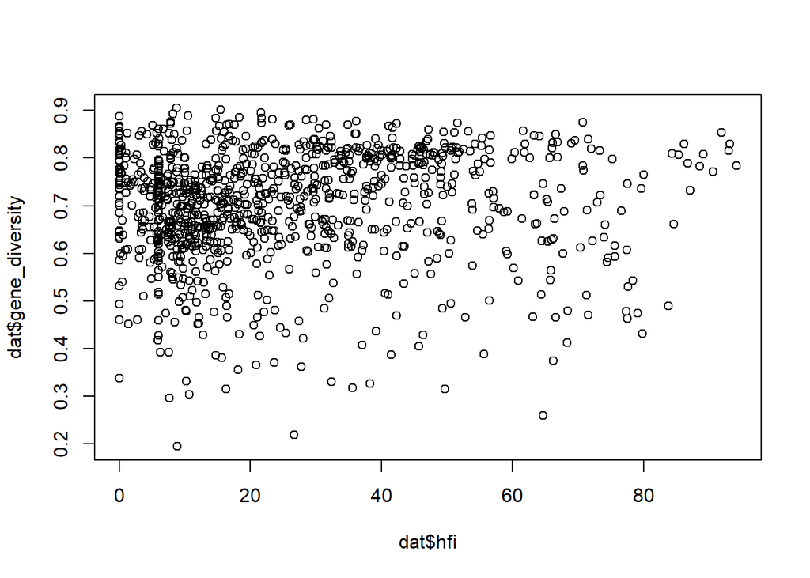

```r
plot(dat$gene_diversity ~ dat$hfi)
```

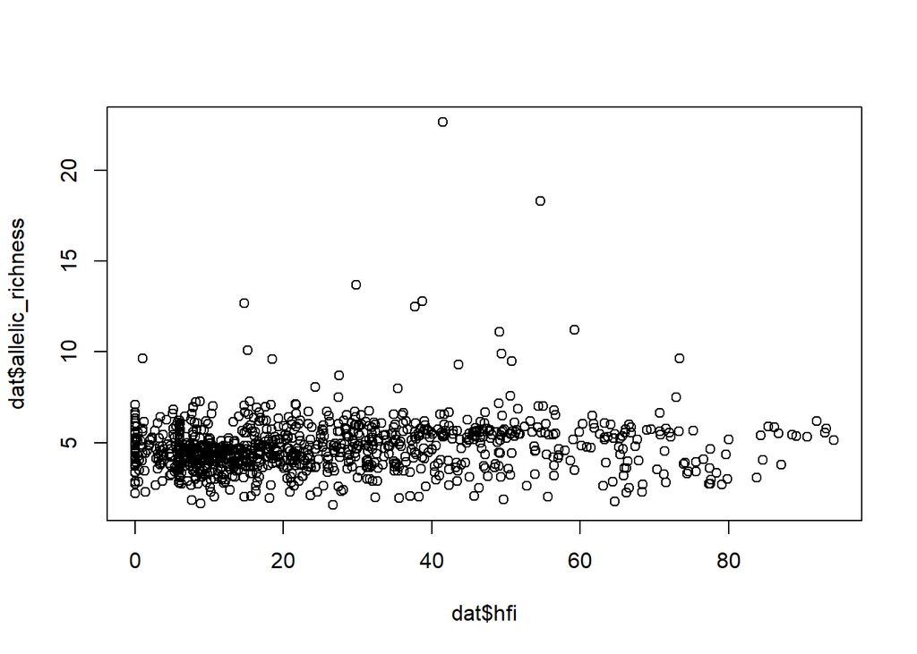

```r
plot(dat$allelic_richness ~ dat$hfi)
```

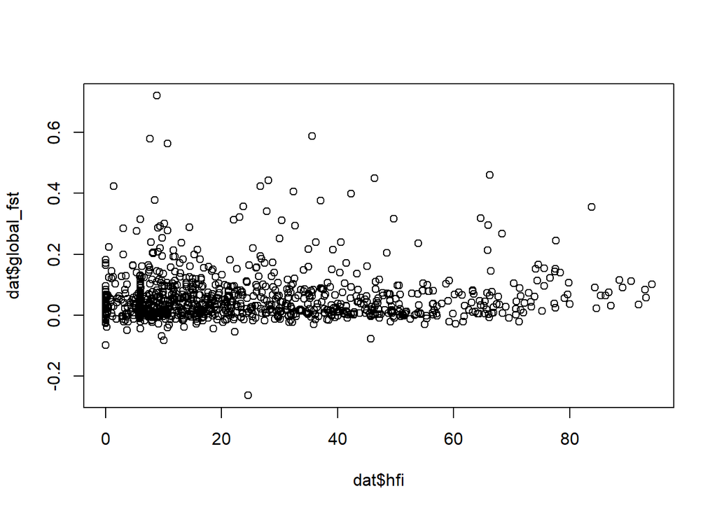

```r
plot(dat$global_fst ~ dat$hfi) # Is there anything funny about this plot?
```

**Q1: how do these plots look for the other urbanization variables, ‘urban’ and ‘popden’?**

We can look at a boxplot for the categorical urban variable:

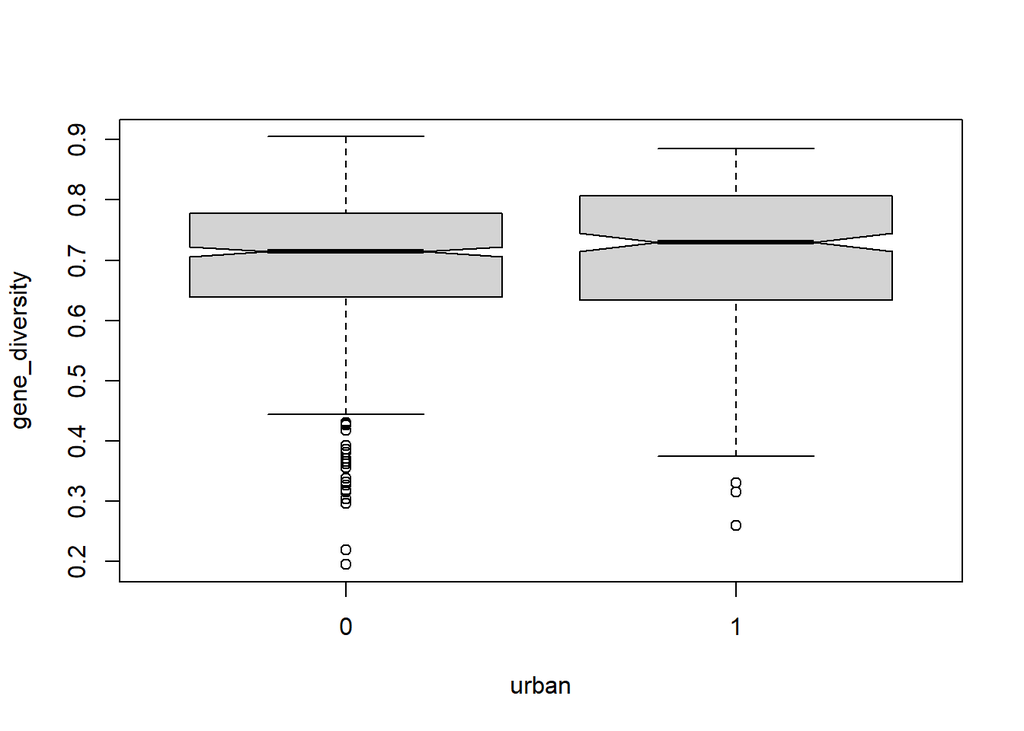

```r
boxplot(gene_diversity~urban, data = dat, notch = TRUE) # What are the notches on boxplots?
```

But, there are 66 species in here, in 2 different taxonomic classes.

**Q2: make a boxplot comparing gene diversity of birds vs mammals. Are they different?**

What about urban vs nonurban birds and mammals?

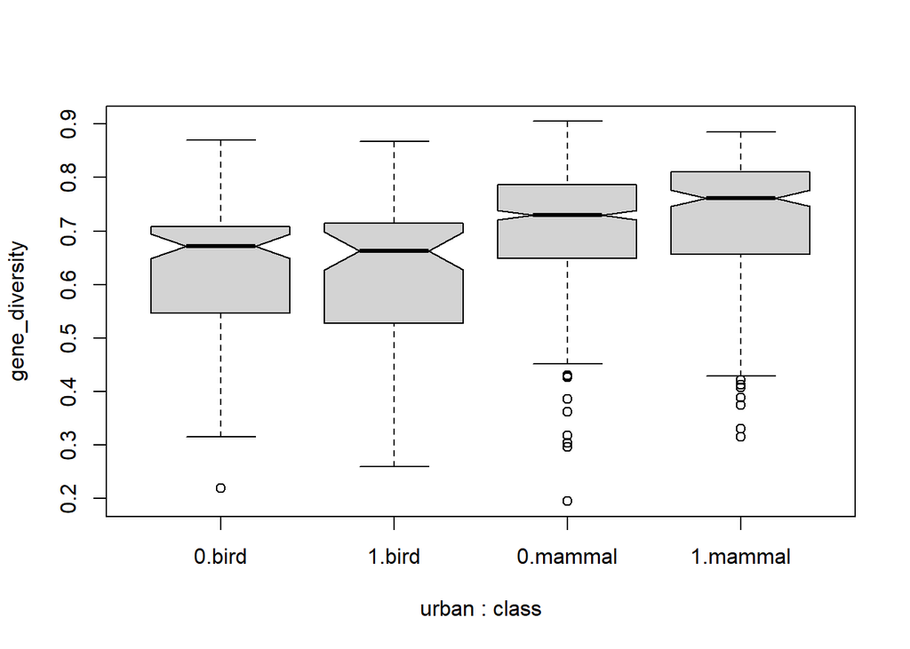

```r
boxplot(gene_diversity~urban + class, data = dat, notch = TRUE)
```

We’ll subset birds and mammals and deal with them separately

```r
mammals <- subset(dat, class == 'mammal')
birds <- subset(dat, class == 'bird')
```

Let’s see whether all species have similar relationships with the Human Footprint Index:

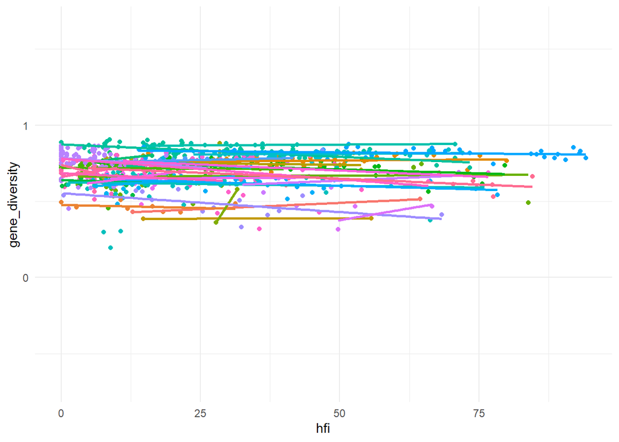

```r
ggplot(mammals, aes(y = gene_diversity, x = hfi, color = species)) +
  geom_point() +
  geom_smooth(method = 'lm', fill = NA) + # add best fit lines per species
  guides(color = 'none') +                # remove legend for now
  theme_minimal()
```

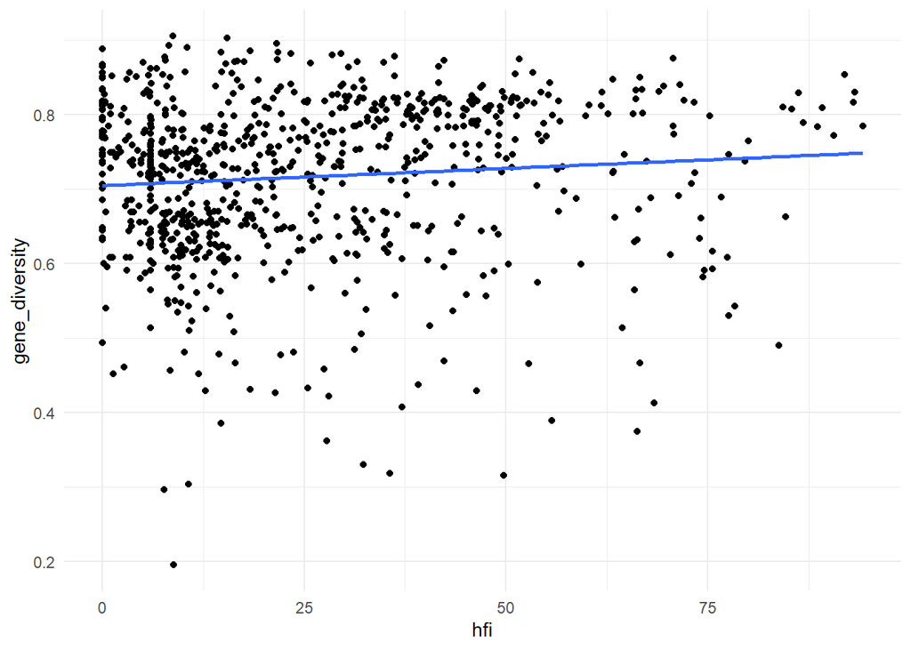

```r
# vs lumping all species:
ggplot(mammals, aes(y = gene_diversity, x = hfi)) +
  geom_point() +
  geom_smooth(method = 'lm', fill = NA) + # add best fit lines per species
  guides(color = 'none') +                # remove legend for now
  theme_minimal()
```

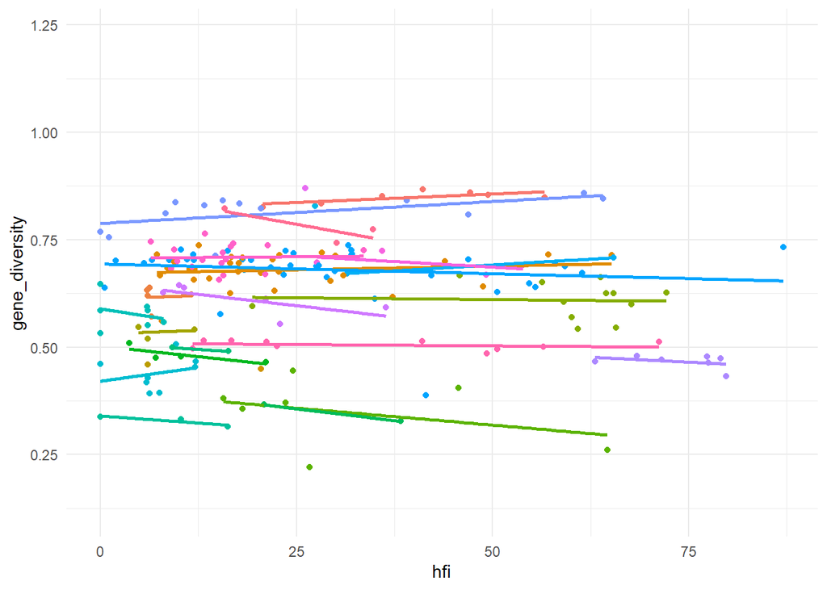

```r
# Repeat for birds:
ggplot(birds, aes(y = gene_diversity, x = hfi, color = species)) +
  geom_point() +
  geom_smooth(method = 'lm', fill = NA) +
  guides(color = 'none') +
  theme_minimal()
```

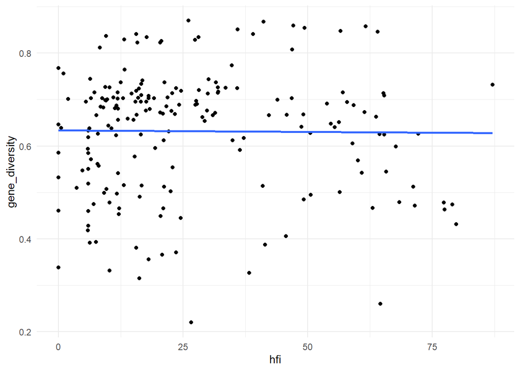

```r
ggplot(birds, aes(y = gene_diversity, x = hfi)) +
  geom_point() +
  geom_smooth(method = 'lm', fill = NA) +
  guides(color = 'none') +
  theme_minimal()
```

There are differences across classes and across species that we should account for in our models.

### 2. Testing effects of urbanization on genetic diversity

For this we will use hierarchical linear models (AKA linear mixed models)

```r
# Scale and center all variables so that models are comparable:
mammals$sc_gd <- scale(mammals$gene_diversity)
mammals$sc_ar <- scale(mammals$allelic_richness)

mammals$sc_hfi <- scale(mammals$hfi)
mammals$sc_pop <- scale(log(mammals$popden))
## Note: we do not need to scale the 'urban' variable: it is a binary factor

# Run a model looking at the effect of the Human Footprint Index on gene diversity:
gd_mod <- lmer(sc_gd ~ sc_hfi + (sc_hfi||species), data = mammals)
summary(gd_mod)
```

```
## Linear mixed model fit by REML. t-tests use Satterthwaite's method [
## lmerModLmerTest]
## Formula: sc_gd ~ sc_hfi + (sc_hfi || species)
##    Data: mammals
##
## REML criterion at convergence: 1515.8
##
## Scaled residuals:
##     Min      1Q  Median      3Q     Max
## -7.1942 -0.3230  0.0872  0.5179  2.0363
##
## Random effects:
##  Groups    Name        Variance Std.Dev.
##  species   (Intercept) 1.22215  1.1055
##  species.1 sc_hfi      0.01797  0.1340
##  Residual              0.30964  0.5565
## Number of obs: 812, groups:  species, 41
##
## Fixed effects:
##             Estimate Std. Error      df t value Pr(>|t|)
## (Intercept)  -0.3353     0.1791 37.9840  -1.872  0.06893 .
## sc_hfi       -0.1353     0.0445 16.1265  -3.040  0.00775 **
## ---
## Signif. codes:  0 '***' 0.001 '**' 0.01 '*' 0.05 '.' 0.1 ' ' 1
##
## Correlation of Fixed Effects:
##        (Intr)
## sc_hfi 0.011
```

```r
ar_mod <- lmer(sc_ar ~ sc_hfi + (sc_hfi||species), data = mammals)
summary(ar_mod)
```

```
## Linear mixed model fit by REML. t-tests use Satterthwaite's method [
## lmerModLmerTest]
## Formula: sc_ar ~ sc_hfi + (sc_hfi || species)
##    Data: mammals
##
## REML criterion at convergence: 1568.2
##
## Scaled residuals:
##     Min      1Q  Median      3Q     Max
## -4.0028 -0.3224  0.0169  0.3236  9.0149
##
## Random effects:
##  Groups    Name        Variance Std.Dev.
##  species   (Intercept) 0.823072 0.90723
##  species.1 sc_hfi      0.002573 0.05072
##  Residual              0.342040 0.58484
## Number of obs: 812, groups:  species, 41
##
## Fixed effects:
##             Estimate Std. Error      df t value Pr(>|t|)
## (Intercept)  -0.2326     0.1494 39.6349  -1.557 0.127377
## sc_hfi       -0.1562     0.0331 11.6493  -4.720 0.000538 ***
## ---
## Signif. codes:  0 '***' 0.001 '**' 0.01 '*' 0.05 '.' 0.1 ' ' 1
##
## Correlation of Fixed Effects:
##        (Intr)
## sc_hfi 0.000
```

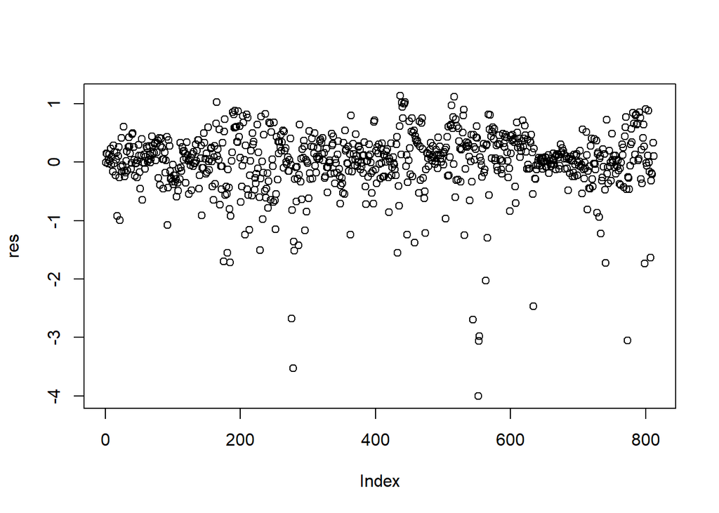

```r
# Check the model residuals:
res <- residuals(gd_mod)
plot(res)
```

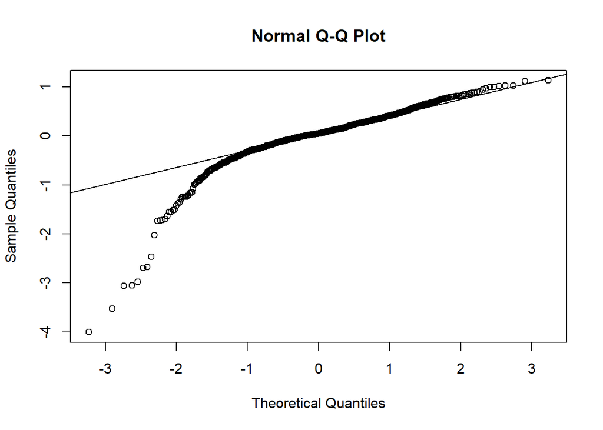

```r
qqnorm(res)
qqline(res)
```

**Q3: Does the Human Footprint Index affect gene diversity?**

**Q4: Are effects consistent across alpha diversity metrics?**

Try to test the effects of other urbanization variables on gene diversity and allelic richness.

*What do you predict you’ll find? Do your predictions hold?*

**Q5: How does urbanization affect beta diversity (differentiation)?**

Try to test the effects of other urbanization variables on population-specific FST (called *global_fst* in this dataset).

**Note:** there are NA values for FST in this dataset. Start by making a subset of the data where NA values are ommitted, then rescale the variables you need.

*What do you predict you’ll find? Do your predictions hold?*

### Plot results

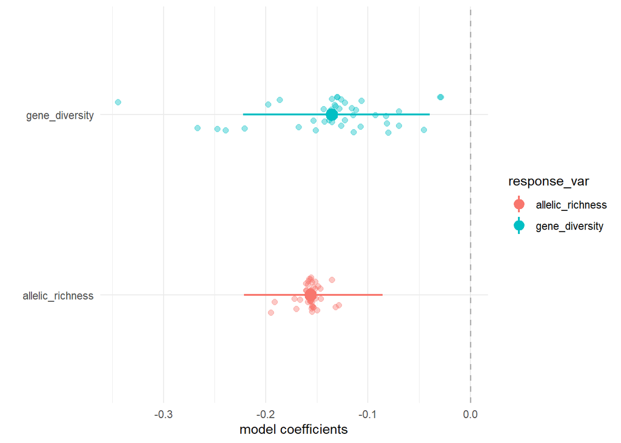

```r
# Create a list of models
model_list <- list(gd_mod, ar_mod)

# Make a plot for 1 predictor variable (here HFI):
predictor_list <- as.list(rep('sc_hfi', length(model_list)))

response_list <- list('gene_diversity', 'allelic_richness')

# Extract summaries from all models at once:
x <- Map(function(mod, var, resp) plot_format(model = mod, predictor = var, response = resp),
         mod = model_list, var = predictor_list, resp = response_list)

plotdata <- do.call('rbind', x) # combine the data into a single dataframe

## Make the plot:
ggplot(data = plotdata, aes(x = response_var, color = response_var)) + # change as needed
  geom_hline(yintercept = 0, lty = 'dashed', color = 'gray70', lwd = 0.6) +
  geom_jitter(aes(y = species_effect), width = 0.1, size = 2, alpha = 0.4) +
  geom_pointrange(aes(y = main_effect, ymin = lower_95, ymax = upper_95),
                  size = 0.75, fatten = 5) +
  coord_flip() +
  labs(x = '', y = 'model coefficients') +
  theme_minimal()
```